# The COVID-19 Pandemic, Mask Use, and Vaccinations in Counties Across the United States

# **1. COVID Deaths Nationally**

Fig. 1 demonstrates the COVID-19 deaths per county to date. The x-axis represents the number of deaths per county, while the y-axis shows the percentage of counties. The histogram below shows that most of the counties had a median of 96 COVID-19 deaths. The average COVID-19 deaths to date was approximately 296.99.

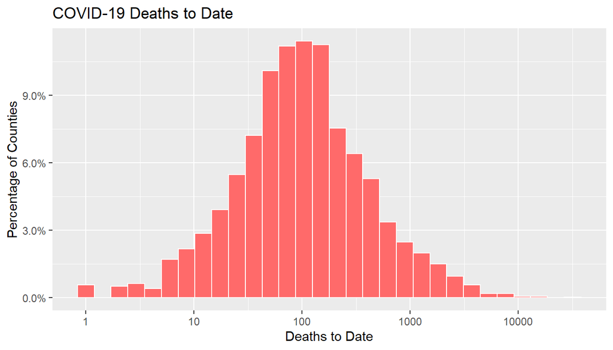

Fig. 1 Deaths to Date

In the the table below, we can see the top 10 counties with the highest numbers of deaths to date. Los Angeles County (LA) had the highest number of COVID-19 deaths to date, which was 31,754 deaths. This is a significant outlier, as LA’s number of deaths is significantly higher than the rest of the top ranking counties.

Top 10 Counties with Highest Deaths to Date

| Deaths to Date | State | County |
| --- | --- | --- |
| 31754 | CA | Los Angeles County |
| 17004 | AZ | Maricopa County |
| 14838 | IL | Cook County |
| 10891 | TX | Harris County |
| 10800 | FL | Miami-Dade County |
| 7897 | MI | Wayne County |
| 7825 | NV | Clark County |
| 6919 | CA | Orange County |
| 6883 | CA | San Bernardino County |
| 6722 | TX | Dallas County |

In the the table below, we can see the top 10 counties with the lowest numbers of COVID-19 deaths to date, which was 0. There are an additional 10 counties that had 0 COVID-19 deaths to date.

Top 10 Counties with Lowest Deaths to Date

| Deaths to Date | State | County |
| --- | --- | --- |
| 0 | AK | Skagway Municipality |
| 0 | CO | Hinsdale County |
| 0 | CO | Jackson County |
| 0 | CO | San Juan County |
| 0 | NE | Hayes County |
| 0 | NE | Keya Paha County |
| 0 | ND | Slope County |
| 0 | UT | Daggett County |
| 0 | UT | Rich County |
| 0 | UT | Wayne County |

# **2. Estimated Rates of Mask Use: What Percentage of the Population “Always” Wore a Mask?**

Fig. 2 demonstrates a histogram of the percentage of the population that always wore a mask. The x-axis represents the percentage of the population that always wore a mask, and the y-axis shows the percentage of counties. Approximately 7 percent of the counties had a median of 49.7 percent of the population that always wore a mask. The mean population that always wore a mask is 50.77 percent.

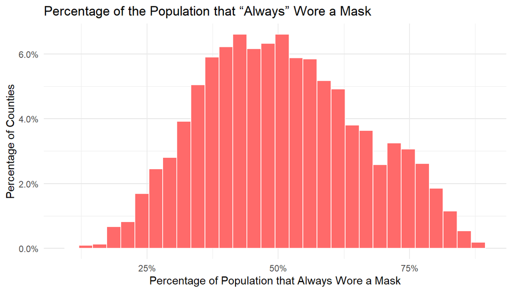

Fig. 2 Always Wore a Mask

In the table below, we can see the top 10 counties that had the highest percentage of the population that always wore a mask. Yates County had the highest percentage of the population that always wore a mask (88.4%).

Top 10 Counties that Always Wore a Mask

| Always Wore a Mask | State | County |
| --- | --- | --- |
| 0.884 | NY | Yates County |
| 0.880 | TX | Hudspeth County |
| 0.877 | TX | El Paso County |
| 0.872 | NV | Esmeralda County |
| 0.865 | CA | Humboldt County |
| 0.864 | NY | Seneca County |
| 0.861 | NY | Wyoming County |
| 0.857 | MA | Hampshire County |
| 0.856 | DE | Sussex County |
| 0.855 | TX | Hays County |

In the table below, we can see the top 10 counties with the lowest percentage of the population that always wore a mask. Valley County has the lowest percentage of the population that always wore a mask (11.5%).

10 Lowest Counties that Always Wore a Mask

| Always Wore a Mask | State | County |
| --- | --- | --- |
| 0.115 | MT | Valley County |
| 0.129 | MT | Daniels County |
| 0.139 | MT | McCone County |
| 0.146 | MT | Roosevelt County |
| 0.147 | MT | Phillips County |
| 0.155 | MO | Wright County |
| 0.161 | MT | Dawson County |
| 0.164 | MO | Pike County |
| 0.175 | UT | Uintah County |
| 0.176 | MT | Prairie County |